# Hillforts Primer

## An Analysis of the Atlas of Hillforts of Britain and Ireland

## Appendix 1

Mike Middleton, March 2022  
https://orcid.org/0000-0001-5813-6347

## Part 1: Name, Admin & Location Data

[Colab Notebook: Live code](https://colab.research.google.com/drive/1pcJkVos5ltkR1wMp7nudJBYLTcep9k9b?usp=sharing) (Must be logged into Google. Select Google Colaboratory, at the top of the screen, if page opens as raw code)  
[HTML: Read only](https://www.dairsieonline.co.uk/hillforts/hillforts_primer_part_01.html)  
[HTML: Read only topographic](https://www.dairsieonline.co.uk/hillforts/hillforts_primer_part_01-topo.html)

## Part 2: Management & Landscape

[Colab Notebook: Live code](https://colab.research.google.com/drive/1yRwVJAr6JljJGVeMLE0SB7fTQ0pHdQPp?usp=sharing)  
[HTML: Read only](https://www.dairsieonline.co.uk/hillforts/hillforts_primer_part_02.html)  
[HTML: Read only topographic](https://www.dairsieonline.co.uk/hillforts/hillforts_primer_part_02-topo.html)

## Part 3: Boundary & Dating

[Colab Notebook: Live code](https://colab.research.google.com/drive/1dMKByCmq33hjniGZImBjUYUj785_71CT?usp=sharing)  
[HTML: Read only](https://www.dairsieonline.co.uk/hillforts/hillforts_primer_part_03.html)  
[HTML: Read only topographic](https://www.dairsieonline.co.uk/hillforts/hillforts_primer_part_03-topo.html)

## Part 4: Investigations & Interior

[Colab Notebook: Live code](https://colab.research.google.com/drive/1rNXpURD4K5aglEFhve_lPHWLXOflej2I?usp=sharing)  
[HTML: Read only](https://www.dairsieonline.co.uk/hillforts/hillforts_primer_part_04.html)  
[HTML: Read only topographic](https://www.dairsieonline.co.uk/hillforts/hillforts_primer_part_04-topo.html)

## **Part 5: Entrance, Enclosing & Annex**

[Colab Notebook: Live code](https://colab.research.google.com/drive/1OTDROidFmUjr8bqZJld0tPyjWd-gdSMn?usp=sharing)  
[HTML: Read only](https://www.dairsieonline.co.uk/hillforts/hillforts_primer_part_05.html)  
[HTML: Read only topographic](https://www.dairsieonline.co.uk/hillforts/hillforts_primer_part_05-topo.html)

- Entrance Data
- Enclosing Data
- Annex Data
- Reference Data
- Acknowledgements

# User Settings

Pre-processed data and images are available for download (without the need to run the code in these files) here:  
https://github.com/MikeDairsie/Hillforts-Primer.  
To download, save images or to change the background image to show the topography, first save a copy of this document into your Google Drive folder. Once saved, change download_data, save_images and/or show_topography to **True**, in the code blocks below, **Save** and then select **Runtime>Run all**, in the main menu above, to rerun the code. If selected, running the code will initiate the download and saving of files. Each document will download a number of data packages and you may be prompted to **allow** multiple downloads. Be patient, downloads may take a little time after the document has finish running. Note that each part of the Hillforts Primer is independent and the download, save_image and show_topography variables will need to be enabled in each document, if this functionality is required. Also note that saving images will activate the Google Drive folder and this will request the user to **allow** access. Selecting show_topography will change the background image to a colour topographic map. It should also be noted that, if set to True, this view will only show the distribution of the data selected. It will not show the overall distribution as a grey background layer as is seen when using the simple coastal outlines.

```python
download_data = False
```

```python
save_images = False
```

```python
show_topography = False
```

# Bypass Code Setup

The initial sections of all the Hillforts Primer documents set up the coding environment and define functions used to plot, reprocess and save the data. If you would like to bypass the setup, please use the following link:  
Go to Appendix 1.

# Reload Data and Python Functions

This study is split over multiple documents. Each file needs to be configured and have the source data imported. As this section does not focus on the assessment of the data it is minimised to facilitate the documents readability.

## Python Modules and Code Setup

The Python imports enable the Hillforts Atlas data to be analysed and mapped within this document. The Python code can be run on demand, (see: User Settings). This means that as new research becomes available, the source for this document can be updated to a revised copy of the Atlas data and the impact of that research can be reviewed using the same code and graphic output. The Hillforts Atlas is a baseline and this document is a tool that can be used to assess the impact new research is making in this area.

```python
import sys
print(f'Python: {sys.version}')

import sklearn
print(f'Scikit-Learn: {sklearn.__version__}')

import pandas as pd
print(f'pandas: {pd.__version__}')

import numpy as np
print(f'numpy: {np.__version__}')

%matplotlib inline
import matplotlib
print(f'matplotlib: {matplotlib.__version__}')
import matplotlib.pyplot as plt
import matplotlib.cm as cm
import matplotlib.patches as mpatches
import matplotlib.patches as patches
from matplotlib.cbook import boxplot_stats
from matplotlib.lines import Line2D
import matplotlib.cm as cm

import seaborn as sns
print(f'seaborn: {sns.__version__}')
sns.set(style="whitegrid")

import scipy
print(f'scipy: {scipy.__version__}')
from scipy import stats
from scipy.stats import gaussian_kde

import os
import collections
import math
import random
import PIL
import urllib
random.seed(42) # A random seed is used to ensure that the random numbers created are the same for each run of this document.

from slugify import slugify

# Import Google colab tools to access Drive
from google.colab import drive
```

```
Python: 3.10.11 (main, Apr  5 2023, 14:15:10) [GCC 9.4.0]
Scikit-Learn: 1.2.2
pandas: 1.5.3
numpy: 1.22.4
matplotlib: 3.7.1
seaborn: 0.12.2
scipy: 1.10.1
```

Ref: https://www.python.org/  
Ref: https://scikit-learn.org/stable/  
Ref: https://pandas.pydata.org/docs/  
Ref: https://numpy.org/doc/stable/  
Ref: https://matplotlib.org/  
Ref: https://seaborn.pydata.org/  
Ref: https://docs.scipy.org/doc/scipy/index.html  
Ref: https://pypi.org/project/python-slugify/

### Plot Figures and Maps functions

The following functions will be used to plot data later in the document.

```python
def show_records(plt, plot_data):
    text_colour = 'k'
    if show_topography == True:
        text_colour = 'w'
    plt.annotate(str(len(plot_data))+' records', xy=(-1180000, 6420000), xycoords='data', ha='left', color=text_colour)
```

```python
def get_backgrounds():
    if show_topography == True:
        backgrounds = ["hillforts-topo-01.png",
                    "hillforts-topo-north.png",
                    "hillforts-topo-northwest-plus.png",
                    "hillforts-topo-northwest-minus.png",
                    "hillforts-topo-northeast.png",
                    "hillforts-topo-south.png",
                    "hillforts-topo-south-plus.png",
                    "hillforts-topo-ireland.png",
                    "hillforts-topo-ireland-north.png",
                    "hillforts-topo-ireland-south.png"]
    else:
        backgrounds = ["hillforts-outline-01.png",
                    "hillforts-outline-north.png",
                    "hillforts-outline-northwest-plus.png",
                    "hillforts-outline-northwest-minus.png",
                    "hillforts-outline-northeast.png",
                    "hillforts-outline-south.png",
                    "hillforts-outline-south-plus.png",
                    "hillforts-outline-ireland.png",
                    "hillforts-outline-ireland-north.png",
                    "hillforts-outline-ireland-south.png"]
    return backgrounds
```

```python
def get_bounds():
    bounds = [[-1200000,220000,6400000,8700000],
    [-1200000,220000,7000000,8700000],
    [-1200000,-480000,7000000,8200000],
    [-900000,-480000,7100000,8200000],
    [-520000, 0,7000000,8700000],
    [-800000,220000,6400000,7100000],
    [-1200000,220000,6400000,7100000],
    [-1200000,-600000,6650000,7450000],
    [-1200000,-600000,7050000,7450000],
    [-1200000,-600000,6650000,7080000]]
    return bounds
```

```python
def show_background(plt, ax, location=""):
    backgrounds = get_backgrounds()
    bounds = get_bounds()
    folder = "https://raw.githubusercontent.com/MikeDairsie/Hillforts-Primer/main/hillforts-topo/"

    if location == "n":
        background = os.path.join(folder, backgrounds[1])
        bounds = bounds[1]
    elif location == "nw+":
        background = os.path.join(folder, backgrounds[2])
        bounds = bounds[2]
    elif location == "nw-":
        background = os.path.join(folder, backgrounds[3])
        bounds = bounds[3]
    elif location == "ne":
        background = os.path.join(folder, backgrounds[4])
        bounds = bounds[4]
    elif location == "s":
        background = os.path.join(folder, backgrounds[5])
        bounds = bounds[5]
    elif location == "s+":
        background = os.path.join(folder, backgrounds[6])
        bounds = bounds[6]
    elif location == "i":
        background = os.path.join(folder, backgrounds[7])
        bounds = bounds[7]
    elif location == "in":
        background = os.path.join(folder, backgrounds[8])
        bounds = bounds[8]
    elif location == "is":
        background = os.path.join(folder, backgrounds[9])
        bounds = bounds[9]
    else:
        background = os.path.join(folder, backgrounds[0])
        bounds = bounds[0]

    img = np.array(PIL.Image.open(urllib.request.urlopen(background)))
    ax.imshow(img, extent=bounds)
```

```python
def get_counts(data):
    data_counts = []
    for col in data.columns:
        count = len(data[data[col] == 'Yes'])
        data_counts.append(count)
    return data_counts
```

```python
def add_annotation_plot(ax):
    ax.annotate("Middleton, M. 2022, Hillforts Primer", size='small', color='grey', xy=(0.01, 0.01), xycoords='figure fraction', horizontalalignment = 'left')
    ax.annotate("Source Data: Lock & Ralston, 2017. hillforts.arch.ox.ac.uk", size='small', color='grey', xy=(0.99, 0.01), xycoords='figure fraction', horizontalalignment = 'right')
```

```python
def add_annotation_l_xy(ax):
    ax.annotate("Middleton, M. 2022, Hillforts Primer", size='small', color='grey', xy=(0.01, 0.035), xycoords='figure fraction', horizontalalignment = 'left')
    ax.annotate("Source Data: Lock & Ralston, 2017. hillforts.arch.ox.ac.uk", size='small', color='grey', xy=(0.99, 0.035), xycoords='figure fraction', horizontalalignment = 'right')
```

```python
def plot_bar_chart(data, split_pos, x_label, y_label, title, clip=False):
    fig = plt.figure(figsize=(12,5))
    ax = fig.add_axes([0,0,1,1])
    x_data = data.columns
    x_data = [x.split("_")[split_pos:] for x in x_data]
    x_data_new = []
    for l in x_data :
        txt =  ""
        for part in l:
            txt += "_" + part
        x_data_new.append(txt[1:])
    if clip:
        x_data_new = x_data_new[:-1]
        new_data = data.copy()
        data = new_data.drop(['Dating_Date_Unknown'], axis=1)
    y_data = get_counts(data)
    ax.bar(x_data_new,y_data)
    ax.set_xlabel(x_label)
    ax.set_ylabel(y_label)
    add_annotation_plot(ax)
    plt.title(get_print_title(title))
    save_fig(title)
    plt.show()
```

```python
def plot_bar_chart_using_two_tables(x_data, y_data, x_label, y_label, title):
    fig = plt.figure(figsize=(12,5))
    ax = fig.add_axes([0,0,1,1])
    ax.bar(x_data,y_data)
    ax.set_xlabel(x_label)
    ax.set_ylabel(y_label)
    add_annotation_plot(ax)
    plt.title(get_print_title(title))
    save_fig(title)
    plt.show()
```

```python
def plot_bar_chart_numeric(data, split_pos, x_label, y_label, title, n_bins, extra=''):
    new_data = data.copy()
    fig = plt.figure(figsize=(12,5))
    ax = fig.add_axes([0,0,1,1])
    data[x_label].plot(kind='hist', bins = n_bins)
    ax.set_xlabel(x_label)
    ax.set_ylabel(y_label)
    add_annotation_plot(ax)
    title = f'{title} {extra}'
    plt.title(get_print_title(title))
    save_fig(title)
    plt.show()
```

```python
def plot_continuous(data, x_lable, title):
    fig = plt.figure(figsize=(12,8))
    ax = fig.add_axes([0,0,1,1])
    ax.set_xlabel(x_lable)
    plt.plot(data, linewidth=4)
    plt.ticklabel_format(style='plain')
    plt.title(get_print_title(title))
    add_annotation_plot(ax)
    save_fig(title)
    plt.show()
```

```python
def plot_data_range(data, feature, o="v"):
    fig = plt.figure(figsize=(12,2))
    ax = fig.add_axes([0,0,1,1])
    ax.set_xlabel(feature)
    add_annotation_plot(ax)
    plt.title(get_print_title(feature + " Range"))
    plt.ticklabel_format(style='plain')
    if o == "v":
        sns.boxplot(data=data, orient="v", whis=[2.2, 97.8])
    else:
        sns.boxplot(data=data, orient="h", whis=[2.2, 97.8])
    save_fig(feature + " Range")
    plt.show()

    bp = boxplot_stats(data, whis=[2.2, 97.8])

    low = bp[0].get('whislo')
    q1 = bp[0].get('q1')
    median =  bp[0].get('med')
    q3 = bp[0].get('q3')
    high = bp[0].get('whishi')

    return [low, q1, median, q3, high]
```

```python
def plot_data_range_plus(data, feature, o="v"):
    fig = plt.figure(figsize=(12,8))
    ax = fig.add_axes([0,0,1,1])
    ax.set_xlabel(feature)
    add_annotation_plot(ax)
    plt.title(get_print_title(feature + " Range (Outlier Steps)"))
    plt.ticklabel_format(style='plain')
    if o == "v":
        sns.boxplot(data=data, orient="v", whis=[2.2, 97.8])
    else:
        sns.boxplot(data=data, orient="h", whis=[2.2, 97.8])

    # Add annotation lines
    x = [24, 24, 54, 54]
    y = [-0.05, -0.075, -0.075, -0.05]
    x1 = [54, 54, 84, 84]
    y1 = [-0.1, -0.125, -0.125, -0.1]
    x2 = [84, 84, 114, 114]
    y2 = [-0.05, -0.075, -0.075, -0.05]

    line_1 = plt.plot(x,y)
    line_2 = plt.plot(x1,y1)
    line_3 = plt.plot(x2,y2)

    # Add annotation text
    text_kwargs = dict(ha='center', va='center', fontsize=16, color='k')
    plt.text(39, -0.1, '30 Ha', **text_kwargs)
    plt.text(69, -0.1, '30 Ha', **text_kwargs)
    plt.text(99, -0.1, '30 Ha', **text_kwargs)

    save_fig(feature + " Range")
    plt.show()

    return
```

```python
def location_XY_plot():
    plt.ticklabel_format(style='plain')
    plt.xlim(-1200000,220000)
    plt.ylim(6400000,8700000)
    add_annotation_l_xy(plt)
```

```python
def add_grey(region=''):
    if show_topography == False:
        # plots all the hillforts as a grey background
        loc = location_data.copy()
        if region == 's':
            loc = loc[loc['Location_Y'] < 8000000].copy()
            loc = loc[loc['Location_X'] > -710000].copy()
        elif region == 'ne':
            loc = loc[loc['Location_Y'] < 8000000].copy()
            loc = loc[loc['Location_X'] > -800000].copy()

        plt.scatter(loc['Location_X'], loc['Location_Y'], c='Silver')
```

```python
def plot_over_grey_numeric(merged_data, a_type, title, extra="", inner=False, fringe=False, oxford=False,swindon=False):
    plot_data = merged_data
    fig, ax = plt.subplots(figsize=(14.2 * 0.66, 23.0 * 0.66))
    show_background(plt, ax)
    location_XY_plot()
    add_grey()
    patches = add_oxford_swindon(oxford,swindon)
    plt.scatter(plot_data['Location_X'], plot_data['Location_Y'], c='Red')
    if fringe:
        f_for_legend = add_21Ha_fringe()
        patches.append(f_for_legend)
    if inner:
        i_for_legend = add_21Ha_line()
        patches.append(i_for_legend)
    show_records(plt, plot_data)
    plt.legend(loc='upper left', handles= patches)
    plt.title(get_print_title(title))
    save_fig(title)
    plt.show()
    print(f'{round(((len(plot_data)/4147)*100), 2)}%')
```

```python
def plot_over_grey_boundary(merged_data, a_type, boundary_type):
    plot_data = merged_data[merged_data[a_type] == boundary_type]
    fig, ax = plt.subplots(figsize=(9.47, 15.33))
    show_background(plt, ax)
    location_XY_plot()
    add_grey(region='')
    plt.scatter(plot_data['Location_X'], plot_data['Location_Y'], c='Red')
    show_records(plt, plot_data)
    plt.title(get_print_title('Boundary_Type: ' + boundary_type))
    save_fig('Boundary_Type_' + boundary_type)
    plt.show()
```

```python
def add_21Ha_line():
    x_values = [-367969, -344171, -263690, -194654, -130542, -119597, -162994, -265052]#, -304545]
    y_values = [7019842, 6944572, 6850593, 6779602, 6735058, 6710127, 6684152, 6663609]#, 6611780]
    plt.plot(x_values, y_values, 'k', ls='-', lw=15, alpha=0.25, label = '≥ 21 Ha Line')
    add_to_legend = Line2D([0], [0], color='k', lw=15, alpha=0.25, label = '≥ 21 Ha Line')
    return add_to_legend
```

```python
def add_21Ha_fringe():
    x_values = [-367969,-126771,29679,-42657,-248650,-304545,-423647,-584307,-367969]
    y_values = [7019842,6847138,6671658,6596650,6554366,6611780,6662041,6752378,7019842]
    plt.plot(x_values, y_values, 'k', ls=':', lw=5, alpha=0.45, label = '≥ 21 Ha Fringe')
    add_to_legend = Line2D([0], [0], color='k', ls=':', lw=5, alpha=0.45, label = '≥ 21 Ha Fringe')
    return add_to_legend
```

```python
def plot_density_over_grey(data, data_type, extra='', inner=False, fringe=False):
    new_data = data.copy()
    new_data = new_data.drop(['Density'], axis=1)
    new_data = add_density(new_data)
    fig, ax = plt.subplots(figsize=((14.2 * 0.66)+2.4, 23.0 * 0.66))
    show_background(plt, ax)
    location_XY_plot()
    add_grey()
    plt.scatter(new_data['Location_X'], new_data['Location_Y'], c=new_data['Density'], cmap=cm.rainbow, s=25)
    if fringe:
        add_21Ha_fringe()
    if inner:
        add_21Ha_line()
        plt.legend(loc='lower left')
    plt.colorbar(label='Density')
    title = f'Density - {data_type} {extra}'
    plt.title(get_print_title(title))
    save_fig(title)
    plt.show()
```

```python
def plot_density_over_grey_three(data_low, data_iqr, data_high, title, extra='', inner=False, fringe=False):
    new_data_low = data_low.copy()
    new_data_low = new_data_low.drop(['Density'], axis=1)
    new_data_low = add_density(new_data_low)

    new_data_iqr = data_iqr.copy()
    new_data_iqr = new_data_iqr.drop(['Density'], axis=1)
    new_data_iqr = add_density(new_data_iqr)

    new_data_high = data_high.copy()
    new_data_high = new_data_high.drop(['Density'], axis=1)
    new_data_high = add_density(new_data_high)

    fig, ax = plt.subplots(1, 3)
    fig.set_figheight(7)
    fig.set_figwidth(15)

    bounds = get_bounds()
    folder = "https://raw.githubusercontent.com/MikeDairsie/Hillforts-Primer/main/hillforts-topo/"
    background = os.path.join(folder, "hillforts-bw-02.png")
    bounds = bounds[0]
    img = plt.imread(background)
    ax[0].imshow(img, extent=bounds)
    ax[1].imshow(img, extent=bounds)
    ax[2].imshow(img, extent=bounds)

    ax[0].scatter(new_data_low['Location_X'], new_data_low['Location_Y'], c=new_data_low['Density'], cmap=cm.rainbow, s=25)
    ax[1].scatter(new_data_iqr['Location_X'], new_data_iqr['Location_Y'], c=new_data_iqr['Density'], cmap=cm.rainbow, s=25)
    ax[2].scatter(new_data_high['Location_X'], new_data_high['Location_Y'], c=new_data_high['Density'], cmap=cm.rainbow, s=25)

    ax[0].get_yaxis().set_visible(False)
    ax[1].get_yaxis().set_visible(False)
    ax[2].get_yaxis().set_visible(False)

    ax[0].get_xaxis().set_visible(False)
    ax[1].get_xaxis().set_visible(False)
    ax[2].get_xaxis().set_visible(False)

    ax[0].set_title("1st Quarter (Tiny Hillforts)")
    ax[1].set_title("IQR (Small to Medium Hillforts)")
    ax[2].set_title("4th Quarter (Large Hillforts)")

    fig.suptitle(get_print_title(title), y=1.08)
    ax[0].annotate("Middleton, M. 2022, Hillforts Primer", size='small', color='grey', xy=(0, -0.1), xycoords='axes fraction', horizontalalignment = 'left')
    ax[2].annotate("Source Data: Lock & Ralston, 2017. hillforts.arch.ox.ac.uk", size='small', color='grey', xy=(1, -0.1), xycoords='axes fraction', horizontalalignment = 'right')
    save_fig(title)
    plt.show()
```

```python
def plot_density_over_grey_four(data_1, data_2, data_3, data_4, title, extra='', inner=False, fringe=False):
    new_data_1 = data_1.copy()
    new_data_1 = new_data_1.drop(['Density'], axis=1)
    new_data_1 = add_density(new_data_1)

    new_data_2 = data_2.copy()
    new_data_2 = new_data_2.drop(['Density'], axis=1)
    new_data_2 = add_density(new_data_2)

    new_data_3 = data_3.copy()
    new_data_3 = new_data_3.drop(['Density'], axis=1)
    new_data_3 = add_density(new_data_3)

    new_data_4 = data_4.copy()
    new_data_4 = new_data_4.drop(['Density'], axis=1)
    new_data_4 = add_density(new_data_4)

    fig, ax = plt.subplots(1, 4)
    fig.set_figheight(7)
    fig.set_figwidth(20)

    bounds = get_bounds()
    folder = "https://raw.githubusercontent.com/MikeDairsie/Hillforts-Primer/main/hillforts-topo/"
    background = os.path.join(folder, "hillforts-bw-02.png")
    bounds = bounds[0]
    img = plt.imread(background)
    ax[0].imshow(img, extent=bounds)
    ax[1].imshow(img, extent=bounds)
    ax[2].imshow(img, extent=bounds)
    ax[3].imshow(img, extent=bounds)

    ax[0].scatter(new_data_1['Location_X'], new_data_1['Location_Y'], c=new_data_1['Density'], cmap=cm.rainbow, s=25)
    ax[1].scatter(new_data_2['Location_X'], new_data_2['Location_Y'], c=new_data_2['Density'], cmap=cm.rainbow, s=25)
    ax[2].scatter(new_data_3['Location_X'], new_data_3['Location_Y'], c=new_data_3['Density'], cmap=cm.rainbow, s=25)
    ax[3].scatter(new_data_4['Location_X'], new_data_4['Location_Y'], c=new_data_4['Density'], cmap=cm.rainbow, s=25)

    ax[0].get_yaxis().set_visible(False)
    ax[1].get_yaxis().set_visible(False)
    ax[2].get_yaxis().set_visible(False)
    ax[3].get_yaxis().set_visible(False)

    ax[0].get_xaxis().set_visible(False)
    ax[1].get_xaxis().set_visible(False)
    ax[2].get_xaxis().set_visible(False)
    ax[3].get_xaxis().set_visible(False)

    ax[0].set_title("NE")
    ax[1].set_title("SE")
    ax[2].set_title("SW")
    ax[3].set_title("NW")

    fig.suptitle(get_print_title(title), y=1.08)
    ax[0].annotate("Middleton, M. 2022, Hillforts Primer", size='small', color='grey', xy=(0, -0.1), xycoords='axes fraction', horizontalalignment = 'left')
    ax[3].annotate("Source Data: Lock & Ralston, 2017. hillforts.arch.ox.ac.uk", size='small', color='grey', xy=(1, -0.1), xycoords='axes fraction', horizontalalignment = 'right')
    save_fig(title)
    plt.show()
```

```python
def plot_density_over_grey_five(data_1, data_2, data_3, data_4, data_5, title, extra='', inner=False, fringe=False):
    new_data_1 = data_1.copy()
    new_data_1 = new_data_1.drop(['Density'], axis=1)
    new_data_1 = add_density(new_data_1)

    new_data_2 = data_2.copy()
    new_data_2 = new_data_2.drop(['Density'], axis=1)
    new_data_2 = add_density(new_data_2)

    new_data_3 = data_3.copy()
    new_data_3 = new_data_3.drop(['Density'], axis=1)
    new_data_3 = add_density(new_data_3)

    new_data_4 = data_4.copy()
    new_data_4 = new_data_4.drop(['Density'], axis=1)
    new_data_4 = add_density(new_data_4)

    new_data_5 = data_5.copy()
    new_data_5 = new_data_5.drop(['Density'], axis=1)
    new_data_5 = add_density(new_data_5)

    fig, ax = plt.subplots(1, 5)
    fig.set_figheight(7)
    fig.set_figwidth(24)

    bounds = get_bounds()
    folder = "https://raw.githubusercontent.com/MikeDairsie/Hillforts-Primer/main/hillforts-topo/"
    background = os.path.join(folder, "hillforts-bw-02.png")
    bounds = bounds[0]
    img = plt.imread(background)
    ax[0].imshow(img, extent=bounds)
    ax[1].imshow(img, extent=bounds)
    ax[2].imshow(img, extent=bounds)
    ax[3].imshow(img, extent=bounds)
    ax[4].imshow(img, extent=bounds)

    ax[0].scatter(new_data_1['Location_X'], new_data_1['Location_Y'], c=new_data_1['Density'], cmap=cm.rainbow, s=25)
    ax[1].scatter(new_data_2['Location_X'], new_data_2['Location_Y'], c=new_data_2['Density'], cmap=cm.rainbow, s=25)
    ax[2].scatter(new_data_3['Location_X'], new_data_3['Location_Y'], c=new_data_3['Density'], cmap=cm.rainbow, s=25)
    ax[3].scatter(new_data_4['Location_X'], new_data_4['Location_Y'], c=new_data_4['Density'], cmap=cm.rainbow, s=25)
    ax[4].scatter(new_data_5['Location_X'], new_data_5['Location_Y'], c=new_data_5['Density'], cmap=cm.rainbow, s=25)

    ax[0].get_yaxis().set_visible(False)
    ax[1].get_yaxis().set_visible(False)
    ax[2].get_yaxis().set_visible(False)
    ax[3].get_yaxis().set_visible(False)
    ax[4].get_yaxis().set_visible(False)

    ax[0].get_xaxis().set_visible(False)
    ax[1].get_xaxis().set_visible(False)
    ax[2].get_xaxis().set_visible(False)
    ax[3].get_xaxis().set_visible(False)
    ax[4].get_xaxis().set_visible(False)

    ax[0].set_title("0")
    ax[1].set_title("1")
    ax[2].set_title("2")
    ax[3].set_title("3")
    ax[4].set_title("4")

    fig.suptitle(get_print_title(title), y=1.08)
    ax[0].annotate("Middleton, M. 2022, Hillforts Primer", size='small', color='grey', xy=(0, -0.1), xycoords='axes fraction', horizontalalignment = 'left')
    ax[4].annotate("Source Data: Lock & Ralston, 2017. hillforts.arch.ox.ac.uk", size='small', color='grey', xy=(1, -0.1), xycoords='axes fraction', horizontalalignment = 'right')
    save_fig(title)
    plt.show()
```

```python
def plot_density_over_grey_six(data_1, data_2, data_3, data_4, data_5, data_6, title, extra='', inner=False, fringe=False):
    new_data_1 = data_1.copy()
    new_data_1 = new_data_1.drop(['Density'], axis=1)
    new_data_1 = add_density(new_data_1)

    new_data_2 = data_2.copy()
    new_data_2 = new_data_2.drop(['Density'], axis=1)
    new_data_2 = add_density(new_data_2)

    new_data_3 = data_3.copy()
    new_data_3 = new_data_3.drop(['Density'], axis=1)
    new_data_3 = add_density(new_data_3)

    new_data_4 = data_4.copy()
    new_data_4 = new_data_4.drop(['Density'], axis=1)
    new_data_4 = add_density(new_data_4)

    new_data_5 = data_5.copy()
    new_data_5 = new_data_5.drop(['Density'], axis=1)
    new_data_5 = add_density(new_data_5)

    new_data_6 = data_6.copy()
    new_data_6 = new_data_6.drop(['Density'], axis=1)
    new_data_6 = add_density(new_data_6)

    fig, ax = plt.subplots(1, 6)
    fig.set_figheight(6)
    fig.set_figwidth(24)

    bounds = get_bounds()
    folder = "https://raw.githubusercontent.com/MikeDairsie/Hillforts-Primer/main/hillforts-topo/"
    background = os.path.join(folder, "hillforts-bw-02.png")
    bounds = bounds[0]
    img = plt.imread(background)
    ax[0].imshow(img, extent=bounds)
    ax[1].imshow(img, extent=bounds)
    ax[2].imshow(img, extent=bounds)
    ax[3].imshow(img, extent=bounds)
    ax[4].imshow(img, extent=bounds)
    ax[5].imshow(img, extent=bounds)

    ax[0].scatter(new_data_1['Location_X'], new_data_1['Location_Y'], c=new_data_1['Density'], cmap=cm.rainbow, s=25)
    ax[1].scatter(new_data_2['Location_X'], new_data_2['Location_Y'], c=new_data_2['Density'], cmap=cm.rainbow, s=25)
    ax[2].scatter(new_data_3['Location_X'], new_data_3['Location_Y'], c=new_data_3['Density'], cmap=cm.rainbow, s=25)
    ax[3].scatter(new_data_4['Location_X'], new_data_4['Location_Y'], c=new_data_4['Density'], cmap=cm.rainbow, s=25)
    ax[4].scatter(new_data_5['Location_X'], new_data_5['Location_Y'], c=new_data_5['Density'], cmap=cm.rainbow, s=25)
    ax[5].scatter(new_data_5['Location_X'], new_data_5['Location_Y'], c=new_data_5['Density'], cmap=cm.rainbow, s=25)

    ax[0].get_yaxis().set_visible(False)
    ax[1].get_yaxis().set_visible(False)
    ax[2].get_yaxis().set_visible(False)
    ax[3].get_yaxis().set_visible(False)
    ax[4].get_yaxis().set_visible(False)
    ax[5].get_yaxis().set_visible(False)

    ax[0].get_xaxis().set_visible(False)
    ax[1].get_xaxis().set_visible(False)
    ax[2].get_xaxis().set_visible(False)
    ax[3].get_xaxis().set_visible(False)
    ax[4].get_xaxis().set_visible(False)
    ax[5].get_xaxis().set_visible(False)

    ax[0].set_title("Part Univallate")
    ax[1].set_title("Univallate")
    ax[2].set_title("Part Bivallate")
    ax[3].set_title("Bivallate")
    ax[4].set_title("Part Multivallate")
    ax[5].set_title("Multivallate")

    fig.suptitle(get_print_title(title), y=1.08)
    ax[0].annotate("Middleton, M. 2022, Hillforts Primer", size='small', color='grey', xy=(0, -0.1), xycoords='axes fraction', horizontalalignment = 'left')
    ax[5].annotate("Source Data: Lock & Ralston, 2017. hillforts.arch.ox.ac.uk", size='small', color='grey', xy=(1, -0.1), xycoords='axes fraction', horizontalalignment = 'right')
    save_fig(title)
    plt.show()
```

```python
def add_oxford_swindon(oxford=False,swindon=False):
    # plots a circle over Swindon & Oxford
    radius = 50
    marker_size = (2*radius)**2
    patches = []
    if oxford:
        plt.scatter(-144362,6758380, c='dodgerblue', s=marker_size, alpha=0.50)
        b_patch = mpatches.Patch(color='dodgerblue', label='Oxford orbit')
        patches.append(b_patch)
    if swindon:
        plt.scatter(-197416, 6721977, c='yellow', s=marker_size, alpha=0.50)
        y_patch = mpatches.Patch(color='yellow', label='Swindon orbit')
        patches.append(y_patch)
    return patches
```

```python
def plot_over_grey(merged_data, a_type, yes_no, extra="", inner=False, fringe=False, oxford=False,swindon=False,topo=False):
    # plots selected data over the grey dots. yes_no controlls filtering the data for a positive or negative values.
    plot_data = merged_data[merged_data[a_type] == yes_no]
    fig, ax = plt.subplots(figsize=(14.2 * 0.66, 23.0 * 0.66))
    show_background(plt, ax)
    location_XY_plot()
    add_grey()
    patches = add_oxford_swindon(oxford,swindon)
    plt.scatter(plot_data['Location_X'], plot_data['Location_Y'], c='Red')
    if fringe:
        f_for_legend = add_21Ha_fringe()
        patches.append(f_for_legend)
    if inner:
        i_for_legend = add_21Ha_line()
        patches.append(i_for_legend)
    show_records(plt, plot_data)
    plt.legend(loc='upper left', handles= patches)
    plt.title(get_print_title(f'{a_type} {extra}'))
    save_fig(f'{a_type}_{extra}')
    plt.show()
    print(f'{round(((len(plot_data)/4147)*100), 2)}%')
    return plot_data
```

```python
def plot_type_values(data, data_type, title,extra=''):
    new_data = data.copy()
    fig, ax = plt.subplots(figsize=((14.2 * 0.66)+2.4, 23.0 * 0.66))
    show_background(plt, ax)
    location_XY_plot()
    add_grey()
    plt.scatter(new_data['Location_X'], new_data['Location_Y'], c=new_data[data_type], cmap=cm.rainbow, s=25)
    plt.colorbar(label=data_type)
    title = f'{data_type} {extra}'
    plt.title(get_print_title(title))
    save_fig(title)
    plt.show()
```

```python
def bespoke_plot(plt, title):
    add_annotation_plot(plt)
    plt.ticklabel_format(style='plain')
    plt.title(get_print_title(title))
    save_fig(title)
    plt.show()
```

```python
def add_cluster_split_lines(plt, ax, extra=None):
    x_min = -550000
    if extra == 'ireland':
        x_min = -1200000
    plt.vlines(x=[-500000], ymin=7070000, ymax=9000000, colors='r', ls='-', lw=3)
    plt.hlines(y=[7070000], xmin=x_min, xmax=200000, colors='r', ls='-', lw=3)
    ax.annotate("N/S split", color='k', xy=(50000, 7090000), xycoords='data')
    ax.annotate("E/W split", color='k', xy=(-480000, 8660000), xycoords='data')
    ax.annotate("Irish Sea split", color='k', xy=(-1150000, 7510000), xycoords='data')
    plot_line((-800000,6400000), (-550000,7070000))
    plot_line((-550000,7070000), (-666000,7440000))
    plot_line((-666000,7440000),(-900000,7500000))
```

```python
def plot_values(data, feature, title, extra=''):
    fig, ax = plt.subplots(figsize=((14.2 * 0.66)+2.4, 23.0 * 0.66))
    show_background(plt, ax)
    location_XY_plot()
    plt.scatter(data['Location_X'], data['Location_Y'], c=data[feature], cmap=cm.rainbow, s=25)
    plt.colorbar(label=feature)
    title = f'{title} {extra}'
    plt.title(title)
    save_fig(title)
    plt.show()
```

```python
def plot_line(point1, point2):
    x_values = [point1[0], point2[0]]
    y_values = [point1[1], point2[1]]
    plt.plot(x_values, y_values, 'r', ls='0', lw=2, alpha=1)
```

```python
def density_scatter_lines(location_data, scatter_data, plot_title, inner=False, fringe=False):
    fig, ax = plt.subplots(figsize=((14.2 * 0.66)+2.0, 23.0 * 0.66))
    show_background(plt, ax)
    location_XY_plot()
    plt.scatter(location_data['Location_X'], location_data['Location_Y'], c=location_data['Density_trans'], cmap=cm.rainbow, s=25)
    plt.colorbar(label='Density Transformed')
    if inner:
        add_21Ha_line()
    if fringe:
        add_21Ha_fringe()
    plt.scatter(scatter_data['Location_X'], scatter_data['Location_Y'], c='Red')
    plt.legend(loc='lower left')
    plt.title(get_print_title(plot_title))
    save_fig(plot_title)
    plt.show()
```

```python
# def south_density_scatter_lines(location_data, scatter_data, plot_title, inner=False, fringe=False, h1=False, limits=False):
#     fig, ax = plt.subplots(figsize=((6.73*1.5)+2.0, (4.62*1.5)))
#     show_background(plt, ax, 's')
#     plt.ticklabel_format(style='plain')
#     plt.xlim(-800000,220000)
#     plt.ylim(6400000,7100000)
#     plt.scatter(location_data['Location_X'], location_data['Location_Y'], c=location_data['Density_trans'], cmap=cm.rainbow, s=25)
#     plt.colorbar(label='Density Transformed')
#     if inner:
#         add_21Ha_line()
#     if fringe:
#         add_21Ha_fringe()
#     if h1:
#         add_h1_line()
#     if limits:
#         add_limits()
#     plt.scatter(scatter_data['Location_X'], scatter_data['Location_Y'], c='red', s=60)
#     add_annotation_plot(plt)
#     plt.legend(loc='lower right')
#     plt.title(get_print_title(plot_title))
#     save_fig(plot_title)
#     plt.show()
```

```python
# def add_h1_line():
#     x_values = [-376969,-119597]
#     y_values = [7019842,6710127]

#     plt.plot(x_values, y_values, 'b', ls='-', lw=8, alpha=0.6, label = 'H1')
```

```python
def add_limits():
    x_values = [-584307,115292]
    y_values = [7019842,7019842]
    xx_values = [115292,115292]
    yy_values = [7019842,6485285]
    xxx_values = [-584307,115292]
    yyy_values = [6485285,6485285]
    x4_values = [-584307, -584307]
    y4_values = [7019842,6485285]


    plt.plot(x_values, y_values, 'g', ls='-', lw=8, alpha=0.6, label = 'Bounds of test')
    plt.plot(xx_values, yy_values, 'g', ls='-', lw=8, alpha=0.6)
    plt.plot(xxx_values, yyy_values, 'g', ls='-', lw=8, alpha=0.6)
    plt.plot(x4_values, y4_values, 'g', ls='-', lw=8, alpha=0.6)
```

```python
def add_linear_south():
    x_values = [-115637,-286900]
    y_values = [6678188,6585812]
    xx_values = [-244249,-363049]
    yy_values = [6555133,6589612]
    xxx_values = [-392213,-363146]
    yyy_values = [6577365,6647256]
    x4_values = [-169664, -207084]
    y4_values = [6599254, 6615290]
    x5_values = [-238560,-200891]
    y5_values = [6668083,6637826]


    plt.plot(x_values, y_values, 'g', ls='-', lw=8, alpha=0.6, label = 'Poss. correlation to linear routes?')
    plt.plot(xx_values, yy_values, 'g', ls='-', lw=8, alpha=0.6)
    plt.plot(xxx_values, yyy_values, 'g', ls='-', lw=8, alpha=0.6)
    plt.plot(x4_values, y4_values, 'g', ls='-', lw=8, alpha=0.6)
    plt.plot(x5_values, y5_values, 'g', ls='-', lw=8, alpha=0.6)
```

```python
def plot_over_grey_south(merged_data, a_type, yes_no, extra=""):
    # plots selected data over the grey dots. yes_no controlls filtering the data for a positive or negative values.
    plot_data = merged_data[merged_data[a_type] == yes_no]
    fig, ax = plt.subplots(1,figsize=((6.73*1.5), (4.62*1.5)))
    show_background(plt, ax, 's')
    plt.ticklabel_format(style='plain')
    plt.xlim(-800000,220000)
    plt.ylim(6400000,7100000)
    add_annotation_l_xy(plt)
    add_grey('s')
    add_linear_south()
    plt.scatter(plot_data['Location_X'], plot_data['Location_Y'], c='Red')
    plt.legend(loc='lower right')
    plt.title(get_print_title(f'{a_type} {extra}'))
    save_fig(f'{a_type}_{extra}')
    plt.show()
    return plot_data
```

```python
def plot_over_grey_north(merged_data, a_type, yes_no, extra="", anno=False):
    # plots selected data over the grey dots. yes_no controlls filtering the data for a positive or negative values.
    plot_data = merged_data[merged_data[a_type] == yes_no]
    fig, ax = plt.subplots(1,figsize=((5.28*2), (5.28*2)))
    show_background(plt, ax, 'n')
    plt.ticklabel_format(style='plain')
    plt.xlim(-800000,0)
    plt.ylim(7200000,8000000)
    if anno == 'Stirling':
        plt.annotate('SC1514: Gillies Hill', xy=(-443187, 7578896), xycoords='data', ha='left', xytext=(-135, 110), textcoords='offset points', arrowprops=dict(arrowstyle="->", color='k', lw=1, connectionstyle="arc3,rad=-0.2"))
        plt.annotate('SC3420: Morebattle Hill', xy=(-263209,7461125), xycoords='data', ha='left', xytext=(-90, -100), textcoords='offset points', arrowprops=dict(arrowstyle="->", color='k', lw=1, connectionstyle="arc3,rad=-0.2"))
        plt.annotate('EN4374: Pike House Camp', xy=(-209365,7418590), xycoords='data', ha='left', xytext=(-10, 80), textcoords='offset points', arrowprops=dict(arrowstyle="->", color='k', lw=1, connectionstyle="arc3,rad=-0.2"))
        plt.annotate('SC3900: Kilmurdie', xy=(-305133,7566913), xycoords='data', ha='left', xytext=(20, 50), textcoords='offset points', arrowprops=dict(arrowstyle="->", color='k', lw=1, connectionstyle="arc3,rad=-0.2"))
    elif anno == 'Traprain':
        plt.annotate('SC3932: Traprain Law', xy=(-297708,7551155), xycoords='data', ha='left', xytext=(35, 80), textcoords='offset points', arrowprops=dict(arrowstyle="->", color='k', lw=1, connectionstyle="arc3,rad=-0.2"))
        plt.annotate('SC3037: Law Hill', xy=(-372530,7642082), xycoords='data', ha='left', xytext=(-150, 12), textcoords='offset points', arrowprops=dict(arrowstyle="->", color='k', lw=1, connectionstyle="arc3,rad=-0.2"))
        plt.annotate("SC3571: Kerr's Knowe", xy=(-367362,7485652), xycoords='data', ha='left', xytext=(-200, 0), textcoords='offset points', arrowprops=dict(arrowstyle="->", color='k', lw=1, connectionstyle="arc3,rad=-0.2"))
        plt.annotate('SC3327: Eildon Hill North', xy=(-301491, 7476601), xycoords='data', ha='left', xytext=(35, 35), textcoords='offset points', arrowprops=dict(arrowstyle="->", color='k', lw=1, connectionstyle="arc3,rad=-0.2"))
    elif anno == 'Kerr':
        plt.annotate("SC3571: Kerr's Knowe", xy=(-367362,7485652), xycoords='data', ha='left', xytext=(-200, 0), textcoords='offset points', arrowprops=dict(arrowstyle="->", color='k', lw=1, connectionstyle="arc3,rad=-0.2"))
    add_annotation_l_xy(plt)
    add_grey('ne')
    plt.scatter(plot_data['Location_X'], plot_data['Location_Y'], c='Red')
    plt.title(get_print_title(f'{a_type} {extra}'))
    save_fig(f'{a_type}_{extra}')
    plt.show()
    return plot_data
```

```python
def get_proportions(date_set):
    total = sum(date_set) - date_set[-1]
    newset = []
    for entry in date_set[:-1]:
        newset.append(round(entry/total,2))
    return newset
```

```python
def plot_dates_by_region(nw,ne,ni,si,s, features):
    fig = plt.figure(figsize=(12,5))
    ax = fig.add_axes([0,0,1,1])
    x_data = nw[features].columns
    x_data = [x.split("_")[2:] for x in x_data][:-1]
    x_data_new = []
    for l in x_data:
        txt =  ""
        for part in l:
            txt += "_" + part
        x_data_new.append(txt[1:])

    set1_name = 'NW'
    set2_name = 'NE'
    set3_name = 'N Ireland'
    set4_name = 'S Ireland'
    set5_name = 'South'
    set1 = get_proportions(get_counts(nw[features]))
    set2 = get_proportions(get_counts(ne[features]))
    set3 = get_proportions(get_counts(ni[features]))
    set4 = get_proportions(get_counts(si[features]))
    set5 = get_proportions(get_counts(s[features]))

    X_axis = np.arange(len(x_data_new))

    budge = 0.25

    plt.bar(X_axis - 0.55 + budge, set1, 0.3, label = set1_name)
    plt.bar(X_axis - 0.4 + budge, set2, 0.3, label = set2_name)
    plt.bar(X_axis - 0.25 + budge, set3, 0.3, label = set3_name)
    plt.bar(X_axis - 0.1 + budge, set4, 0.3, label = set4_name)
    plt.bar(X_axis + 0.05 + budge, set5, 0.3, label = set5_name)

    plt.xticks(X_axis, x_data_new)
    plt.xlabel('Dating')
    plt.ylabel('Proportion of Total Dated Hillforts in Region')
    title = 'Proportions of Dated Hillforts by Region'
    plt.title(title)
    plt.legend()
    add_annotation_plot(ax)
    save_fig(title)
    plt.show()
```

```python
def get_pcent_list(old_list):
    pcnt_list = []
    total = sum(old_list)
    for item in old_list:
        pcnt_list.append(round(item/total,2))
    return pcnt_list
```

```python
def order_set(set_list, x_data, pcnt=False):
    new_list = []
    set_values = set_list.index.tolist()
    for val in x_data:
        if val in set_values:
            new_list.append(set_list.loc[[val]].values[0])
        else:
            new_list.append(0)
    if pcnt:
        new_list = get_pcent_list(new_list)
    return new_list
```

```python
def plot_feature_by_region(nw,ne,ni,si,s, feature, title, clip):
    fig = plt.figure(figsize=(12,5))
    ax = fig.add_axes([0,0,1,1])
    max_val = int(max([nw[feature].max(),ne[feature].max(),ni[feature].max(),si[feature].max(),s[feature].max()]))

    x_data = [x-1 for x in range(max_val+2)]

    set0_name = 'NW'
    set1_name = 'NE'
    set2_name = 'N Ireland'
    set3_name = 'S Ireland'
    set4_name = 'S'

    set0 = nw[feature].value_counts()
    set1 = ne[feature].value_counts()
    set2 = ni[feature].value_counts()
    set3 = si[feature].value_counts()
    set4 = s[feature].value_counts()

    set0 = order_set(set0,x_data, True)[:clip]
    set1 = order_set(set1,x_data, True)[:clip]
    set2 = order_set(set2,x_data, True)[:clip]
    set3 = order_set(set3,x_data, True)[:clip]
    set4 = order_set(set4,x_data, True)[:clip]

    X_axis = np.arange(len(x_data[:clip]))

    budge = 0.2

    plt.bar(X_axis - 0.6 + budge, set0, 0.3, label = set0_name)
    plt.bar(X_axis - 0.45 + budge, set1, 0.3, label = set1_name)
    plt.bar(X_axis - 0.3 + budge, set2, 0.3, label = set2_name)
    plt.bar(X_axis - 0.15 + budge, set3, 0.3, label = set3_name)
    plt.bar(X_axis + 0 + budge, set4, 0.3, label = set4_name)

    plt.xticks(X_axis, x_data)
    plt.xlabel('Number')
    plt.ylabel('Percentage of regional total')
    plt.title(title)
    plt.legend()
    add_annotation_plot(ax)
    save_fig(title)
    plt.show()
```

```python
def plot_quadrents(ramparts,ditches,ne,se,sw,nw):
    fig = plt.figure(figsize=(12,5))
    ax = fig.add_axes([0,0,1,1])
    x_data = [x for x in range(11)]

    set0_name = 'Ramparts'
    set00_name = 'Ditches'
    set1_name = 'NE'
    set2_name = 'SE'
    set3_name = 'SW'
    set4_name = 'NW'
    set0 = ramparts['Enclosing_Max_Ramparts'].value_counts()
    set0 = order_set(set0,x_data)[:8]
    set00 = ditches['Enclosing_Ditches_Number'].value_counts()
    set00 = order_set(set00,x_data)[:8]
    set1 = ne['Enclosing_NE_Quadrant'].value_counts()
    set1 = order_set(set1,x_data)[:8]
    set2 = se['Enclosing_SE_Quadrant'].value_counts()
    set2 = order_set(set2,x_data)[:8]
    set3 = sw['Enclosing_SW_Quadrant'].value_counts()
    set3 = order_set(set3,x_data)[:8]
    set4 = nw['Enclosing_NW_Quadrant'].value_counts()
    set4 = order_set(set4,x_data)[:8]

    X_axis = np.arange(len(x_data[:8]))

    budge = 0.2

    plt.bar(X_axis - 0.6 + budge, set0, 0.2, label = set0_name)
    plt.bar(X_axis - 0.46 + budge, set00, 0.2, label = set00_name)
    plt.bar(X_axis - 0.32 + budge, set1, 0.2, label = set1_name)
    plt.bar(X_axis - 0.18 + budge, set2, 0.2, label = set2_name)
    plt.bar(X_axis - 0.04 + budge, set3, 0.2, label = set3_name)
    plt.bar(X_axis + 0.1 + budge, set4, 0.2, label = set4_name)

    plt.xticks(X_axis, x_data)
    plt.xlabel('Number')
    plt.ylabel('Count')
    title = 'Ditches, Ramparts and Quadrant by Number'
    plt.title(title)
    plt.legend()
    add_annotation_plot(ax)
    save_fig(title)
    plt.show()
```

```python
def plot_regions(nw,ne,ni,si,s, features, xlabel, title, split_pos, yes_no, pcent=False):
    fig = plt.figure(figsize=(12,5))
    ax = fig.add_axes([0,0,1,1])

    x_data = features
    x_data = [x.split("_")[split_pos:] for x in x_data]
    x_data_new = []
    for l in x_data:
        txt =  ""
        for part in l:
            txt += "_" + part
        x_data_new.append(txt[1:])

    set0_name = 'NW'
    set1_name = 'NE'
    set2_name = 'N Ireland'
    set3_name = 'S Ireland'
    set4_name = 'S'

    set0_list = []
    set1_list = []
    set2_list = []
    set3_list = []
    set4_list = []

    for feature in features:
        set0_list.append((nw[feature].values == yes_no).sum())
        set1_list.append((ne[feature].values == yes_no).sum())
        set2_list.append((ni[feature].values == yes_no).sum())
        set3_list.append((si[feature].values == yes_no).sum())
        set4_list.append((s[feature].values == yes_no).sum())

    set0 = set0_list
    set1 = set1_list
    set2 = set2_list
    set3 = set3_list
    set4 = set4_list

    if pcent:
        set0 = get_pcent_list(set0)
        set1 = get_pcent_list(set1)
        set2 = get_pcent_list(set2)
        set3 = get_pcent_list(set3)
        set4 = get_pcent_list(set4)

    X_axis = np.arange(len(x_data))

    budge = 0.3

    plt.bar(X_axis - 0.6 + budge, set0, 0.13, label = set0_name)
    plt.bar(X_axis - 0.45 + budge, set1, 0.13, label = set1_name)
    plt.bar(X_axis - 0.3 + budge, set2, 0.13, label = set2_name)
    plt.bar(X_axis - 0.15 + budge, set3, 0.13, label = set3_name)
    plt.bar(X_axis + 0 + budge, set4, 0.13, label = set4_name)

    plt.xticks(X_axis, x_data_new)
    plt.xlabel(xlabel)
    if pcent:
        plt.ylabel('Percentage of Regional Total')
    else:
        plt.ylabel('Count')
    plt.title(get_print_title(f'{title}'))
    plt.legend()
    add_annotation_plot(ax)
    save_fig(title)
    plt.show()
```

```python
####################
####################
```

# HERE

```python
def plot_data_range_95(data, feature, title, o="v"):
    fig = plt.figure(figsize=(12,2))
    ax = fig.add_axes([0,0,1,1])
    ax.set_xlabel(feature)
    add_annotation_plot(ax)
    plt.title(title)
    plt.ticklabel_format(style='plain')
    plt.axvline(x=mse_h1, color='r', lw=4)
    if o == "v":
        sns.boxplot(data=data, orient="v", whis=[2.5, 97.5])
    else:
        sns.boxplot(data=data, orient="h", whis=[2.5, 97.5])

    plot_title = get_print_title(title)
    save_fig(plot_title)
    plt.show()

    bp = boxplot_stats(data, whis=[2.5, 97.5])

    low = bp[0].get('whislo')
    q1 = bp[0].get('q1')
    median =  bp[0].get('med')
    q3 = bp[0].get('q3')
    high = bp[0].get('whishi')

    return [low, q1, median, q3, high]
```

```python
def plot_mse_hisogram(mse_list, mse_h1):
    fig = plt.figure(figsize=(12,5))
    ax = fig.add_axes([0,0,1,1])
    ax.set_xlabel('MSE')
    ax.set_ylabel('Count')
    plt.ticklabel_format(style='plain')
    plt.hist(mse_list, 100)
    plot_title = get_print_title('Mean Squared Error for hillforts offset from test lines - H1 MSE shown in red.')
    plt.title(plot_title)
    plt.axvline(x=mse_h1, color='r', lw=4)
    add_annotation_plot(ax)
    save_fig(plot_title)
    plt.show()
```

```python
def rotate_around_point(xy, radians, rotation_origin=(0, 0)):
    x, y = xy
    offset_x, offset_y = rotation_origin
    adjusted_x = (x - offset_x)
    adjusted_y = (y - offset_y)
    cos_rad = math.cos(radians)
    sin_rad = math.sin(radians)
    qx = offset_x + cos_rad * adjusted_x + sin_rad * adjusted_y
    qy = offset_y + -sin_rad * adjusted_x + cos_rad * adjusted_y

    return qx, qy
```

```python
def get_random_line(dist):
    test_bounds_x =[-584307, 115292]
    test_bounds_y =[6485285, 7019842]
    rand_point = (random.randrange(test_bounds_x[0],test_bounds_x[1]), random.randrange(test_bounds_y[0],test_bounds_y[1]))
    new_second_point = (-10000000002, 1000000000)

    count = 0
    while (new_second_point[0] <= test_bounds_x[0]) or (new_second_point[0] >= test_bounds_x[1]) or (new_second_point[1] <= test_bounds_y[0]) or (new_second_point[1] >= test_bounds_y[1]):
        rand_second_point = (rand_point[0]+dist, rand_point[1])
        rand_angle_rad = random.uniform(0.0,3.14)
        new_second_point = rotate_around_point(rand_second_point, rand_angle_rad, rand_point)
        count+=1
        if count == 10:
            rand_point = (random.randrange(test_bounds_x[0],test_bounds_x[1]), random.randrange(test_bounds_y[0],test_bounds_y[1]))
            count = 0
    return [rand_point, new_second_point, math.degrees(rand_angle_rad)]
```

```python
def line_intersection(line1, line2):
    x = 1000000
    y = 1000000
    xdiff = (line1[0][0] - line1[1][0], line2[0][0] - line2[1][0])
    ydiff = (line1[0][1] - line1[1][1], line2[0][1] - line2[1][1])

    def det(a, b):
        return a[0] * b[1] - a[1] * b[0]

    div = det(xdiff, ydiff)
    if div == 0:
       pass
    else:
        d = (det(*line1), det(*line2))
        x = det(d, xdiff) / div
        y = det(d, ydiff) / div

    return x, y
```

```python
def show_perpendicular_lines(points, x_values, y_values, angle, scatter_data, show_perpendicular):

    length_divider = 4.85
    distance_list = []

    x_bounds = [-584307,115292]
    y_bounds = [6485285,7019842]
    max_len = math.sqrt( (x_bounds[0] - x_bounds[1])**2 + (y_bounds[0] - y_bounds[1])**2 )
    x0 = points[0][0]
    y0 = points[0][1]
    x1 = points[1][0]
    y1 = points[1][1]
    line_dist = math.sqrt( (x0 - x1)**2 + (y0 - y1)**2 )
    for index, row in scatter_data.iterrows():
        x2 = row['Location_X']
        y2 = row['Location_Y']
        if x2 >= x_bounds[0] and x2 <= x_bounds[1] and y2 >= y_bounds[0] and y2 <= y_bounds[1]:
            p1 = (x2,y2)
            p2 = (x2+max_len,y2)
            new_p2 = p2
            value = ((x1 - x0)*(y2 - y0)) - ((x2 - x0)*(y1 - y0))
            if value < 0:
                pass
                new_p2 = rotate_around_point(p2, math.radians((angle-90)), p1)
            elif value > 0:
                new_p2 = rotate_around_point(p2, math.radians((angle+90)), p1)
            else:
                # on line
                new_p2 = p1
            line1 = ((x_values[0], y_values[0]), (x_values[1], y_values[1]))
            line2 = ((x2, y2), new_p2)
            x3, y3 = line_intersection(line1, line2)

            if x3 == 1000000:
                x3 = x2
                y3 = y2

            px_values = [x2, x3]
            py_values = [y2, y3]

            #set east/west
            west = x0
            east = x1
            if east < west:
                west = x1
                east = x0

            #set north/south
            north = y0
            south = y1
            if east < west:
                north = y1
                greater_than_21ha_south = y0

            if x3 >= west and x3 <= east and y3 >= south and y3 <= north:
                dist = abs(math.sqrt( (px_values[1] - px_values[0])**2 + (py_values[1] - py_values[0])**2 ))
                if dist < line_dist/length_divider:
                    #print(row['Main_Atlas_Number'])
                    distance_list.append(dist)
                    if show_perpendicular:
                        plt.plot(px_values, py_values, 'magenta', ls='-', lw=3, alpha=0.6)
    return distance_list
```

```python
def angle_between(p1, p2):
    ang1 = np.arctan2(*p1[::-1])
    ang2 = np.arctan2(*p2[::-1])
    return np.rad2deg((ang1 - ang2) % (2 * np.pi))
```

```python
def add_h1_line(scatter_data, show_perpendicular_from_main):
    penycloddiau_m = (312888, 367647)
    bozedown_m = (464350, 178250)
    x_values = [-376969,-119597]
    y_values = [7019842,6710127]
    angle_rad = math.atan((bozedown_m[1] - penycloddiau_m[1])/(bozedown_m[0] - penycloddiau_m[0]))
    angle = angle_between((x_values[0], y_values[0]), (x_values[1], y_values[1]))+45

    plt.plot(x_values, y_values, 'b', ls='-', lw=8, alpha=0.6, label = 'H1')

    points = [(x_values[0], y_values[0]), (x_values[1], y_values[1]), angle]

    distance_list = []

    if show_perpendicular_from_main:
        distance_list = show_perpendicular_lines(points, x_values, y_values, angle, scatter_data, show_perpendicular=True)
    return distance_list
```

```python
def add_random_lines(scatter_data, test_lines, dist, show_perpendicular):
    add_lines = test_lines

    distance_lists = []

    for i in range(add_lines):
        points = get_random_line(dist)
        x_values = [points[0][0], points[1][0]]
        y_values = [points[0][1], points[1][1]]
        angle = points[2]
        plt.plot(x_values, y_values, 'darkmagenta', ls='-', lw=3, alpha=0.6)
        distance_list = []

        distance_list = show_perpendicular_lines(points, x_values, y_values, angle, scatter_data, show_perpendicular)
        distance_lists.append(distance_list)
    return distance_lists
```

```python
def south_density_scatter_lines(location_data, scatter_data, plot_title, inner=False, fringe=False, h1=False, limits=False, random_lines=False, test_lines=0, show_perpendicular=False, show_perpendicular_from_main=False):
    penycloddiau = (-367969, 7019842)
    bozedown = (-119597, 6710127)
    dist = math.sqrt( (bozedown[0] - penycloddiau[0])**2 + (bozedown[1] - penycloddiau[1])**2 )
    h1_distance_list = []
    distance_lists = []
    fig, ax = plt.subplots(figsize=((6.73*1.5)+2.0, (4.62*1.5)))
    show_background(plt, ax, 's')
    plt.ticklabel_format(style='plain')
    plt.xlim(-800000,220000)
    plt.ylim(6400000,7100000)
    plt.scatter(location_data['Location_X'], location_data['Location_Y'], c=location_data['Density_trans'], cmap=cm.rainbow, s=25)
    plt.colorbar(label='Density Transformed')
    if inner:
        add_21Ha_line()
    if fringe:
        add_21Ha_fringe()
    if h1:
        h1_distance_list = add_h1_line(scatter_data, show_perpendicular_from_main)
    if limits:
        add_limits()
    if random_lines:
        distance_lists = add_random_lines(scatter_data, test_lines, dist, show_perpendicular)
    plt.scatter(scatter_data['Location_X'], scatter_data['Location_Y'], c='red', s=60)
    add_annotation_plot(plt)
    plt.legend(loc='lower right')
    plt.title(get_print_title(plot_title))
    save_fig(plot_title)
    plt.show()

    return h1_distance_list, distance_lists
```

### Review Data Functions

The following functions will be used to confirm that features are not lost or forgotten when splitting the data.

```python
def test_numeric(data):
    temp_data = data.copy()
    columns = data.columns
    out_cols = ['Feature','Entries', 'Numeric', 'Non-Numeric', 'Null']
    feat, ent, num, non, nul = [],[],[],[],[]
    for col in columns:
        if temp_data[col].dtype == 'object':
            feat.append(col)
            temp_data[col+'_num'] = temp_data[col].str.isnumeric()
            entries = temp_data[col].notnull().sum()
            true_count = temp_data[col+'_num'][temp_data[col+'_num'] == True].sum()
            null_count = temp_data[col].isna().sum()
            ent.append(entries)
            num.append(true_count)
            non.append(entries-true_count)
            nul.append(null_count)
        else:
            print(f'{col} {temp_data[col].dtype}')
    summary = pd.DataFrame(list(zip(feat, ent, num, non, nul)))
    summary.columns = out_cols
    return summary
```

```python
def find_duplicated(numeric_data, text_data, encodeable_data):
    d = False
    all_columns = list(numeric_data.columns) + list(text_data.columns) + list(encodeable_data.columns)
    duplicate = [item for item, count in collections.Counter(all_columns).items() if count > 1]
    if duplicate :
        print(f"There are duplicate features: {duplicate}")
        d = True
    return d
```

```python
def test_data_split(main_data, numeric_data, text_data, encodeable_data):
    m = False
    split_features = list(numeric_data.columns) + list(text_data.columns) + list(encodeable_data.columns)
    missing = list(set(main_data)-set(split_features))
    if missing:
        print(f"There are missing features: {missing}")
        m = True
    return m
```

```python
def review_data_split(main_data, numeric_data, text_data, encodeable_data = pd.DataFrame()):
    d = find_duplicated(numeric_data, text_data, encodeable_data)
    m = test_data_split(main_data, numeric_data, text_data, encodeable_data)
    if d != True and m != True:
        print("Data split good.")
```

```python
def find_duplicates(data):
    print(f'{data.count() - data.duplicated(keep=False).count()} duplicates.')
```

```python
def count_yes(data):
    total = 0
    for col in data.columns:
        count = len(data[data[col] == 'Yes'])
        total+= count
        print(f'{col}: {count}')
    print(f'Total yes count: {total}')
```

### Null Value Functions

The following functions will be used to update null values.

```python
def fill_nan_with_minus_one(data, feature):
    new_data = data.copy()
    new_data[feature] = data[feature].fillna(-1)
    return new_data
```

```python
def fill_nan_with_NA(data, feature):
    new_data = data.copy()
    new_data[feature] = data[feature].fillna("NA")
    return new_data
```

```python
def test_numeric_value_in_feature(feature, value):
    test = feature.isin([-1]).sum()
    return test
```

```python
def test_catagorical_value_in_feature(dataframe, feature, value):
    test = dataframe[feature][dataframe[feature] == value].count()
    return test
```

```python
def test_cat_list_for_NA(dataframe, cat_list):
    for val in cat_list:
        print(val, test_catagorical_value_in_feature(dataframe, val,'NA'))
```

```python
def test_num_list_for_minus_one(dataframe, num_list):
    for val in num_list:
        feature = dataframe[val]
        print(val, test_numeric_value_in_feature(feature, -1))
```

```python
def update_cat_list_for_NA(dataframe, cat_list):
    new_data = dataframe.copy()
    for val in cat_list:
        new_data = fill_nan_with_NA(new_data, val)
    return new_data
```

```python
def update_num_list_for_minus_one(dataframe, cat_list):
    new_data = dataframe.copy()
    for val in cat_list:
        new_data = fill_nan_with_minus_one(new_data, val)
    return new_data
```

### Reprocessing Functions

```python
def add_density(data):
    new_data = data.copy()
    xy = np.vstack([new_data['Location_X'],new_data['Location_Y']])
    new_data['Density'] = gaussian_kde(xy)(xy)
    return new_data
```

## Save Image Functions

```python
# Set-up figure numbering
fig_no = 0
part = 'Appendix1'
IMAGES_PATH = r'/content/drive/My Drive/'
fig_list = pd.DataFrame(columns=['fig_no', 'file_name', 'title'])
topo_txt = ""
if show_topography:
    topo_txt = "-topo"
```

```python
# Remove unicode characters from file names
def get_file_name(title):
    file_name = slugify(title)
    return file_name
```

```python
# Remove underscore from figure titles
def get_print_title(title):
    title = title.replace("_", " ")
    title = title.replace("-", " ")
    title = title.replace(",", ";")
    return title
```

```python
# Format figure numbers to have three digits
def format_figno(no):
    length = len(str(no))
    fig_no = ''
    for i in range(3-length):
        fig_no = fig_no + '0'
    fig_no = fig_no + str(no)
    return fig_no
```

```python
# Mount Google Drive if figures to be saved
if save_images == True:
    drive.mount('/content/drive')
    os.getcwd()
else:
    pass
```

```python
def save_fig(fig_id, tight_layout=True, fig_extension="png", resolution=300):
    global fig_no
    global IMAGES_PATH
    if save_images:
        #IMAGES_PATH = r'/content/drive/My Drive/Colab Notebooks/Hillforts_Primer_Images/HP_Appendix_1_images/'
        fig_no+=1
        fig_no_txt = format_figno(fig_no)
        file_name = file_name = get_file_name(f'{part}_{fig_no_txt}')
        file_name = f'hillforts_primer_{file_name}{topo_txt}.{fig_extension}'
        fig_list.loc[len(fig_list)] = [fig_no, file_name, get_print_title(fig_id)]
        path = os.path.join(IMAGES_PATH, file_name)
        print("Saving figure", file_name)
        plt.tight_layout()
        plt.savefig(path, format=fig_extension, dpi=resolution,  bbox_inches='tight')
    else:
        pass
```

## Load Data

The source csv file is loaded and the first two rows are displayed to confirm the load was successful. Note that, to the left, an index has been added automatically. This index will be used frequently when splitting and remerging data extracts.

```python
hillforts_csv = r"https://raw.githubusercontent.com/MikeDairsie/Hillforts-Primer/main/hillforts-atlas-source-data-csv/hillforts.csv"
hillforts_data = pd.read_csv(hillforts_csv, index_col=False)
pd.set_option('display.max_columns', None, 'display.max_rows', None)
hillforts_data.head(2)
```

|  | OBJECTID | Main_Atlas_Number | Main_Country_Code | Main_Country | Main_Title_Name | Main_Site_Name | Main_Alt_Name | Main_Display_Name | Main_HER | Main_HER_PRN | Main_HER_ID | Main_NMR_Mapsheet | Main_NMR_ID | Main_SM | Main_Summary | Main_Boundary | Main_Coordinate_System | Main_X | Main_Y | Status_Citizen_Science | Status_Citizen | Status_Data_Reliability | Status_Data_Comments | Status_Interpretation_Reliability | Status_Interpretation_Comments | Location_NGR | Location_X | Location_Y | Location_Longitude | … |
| --- | --- | --- | --- | --- | --- | --- | --- | --- | --- | --- | --- | --- | --- | --- | --- | --- | --- | --- | --- | --- | --- | --- | --- | --- | --- | --- | --- | --- | --- | --- |
| 0 | 1 | 1 | EN | England | EN0001 Aconbury Camp, Herefordshire | Aconbury Camp | Aconbury Beacon | Aconbury Camp, Herefordshire (Aconbury Beacon) | Herefordshire | MHE413 | 910 | SO 53 SW 1 | 110371 | 1001754 | Large, wooded, univallate, partial contour hil... | No | OSGB36 | 350350 | 233050 | No | NaN | Confirmed | NaN | Confirmed | NaN | SO 503330 | -303295 | 6798973 | -2.724548 | … |
| 1 | 2 | 2 | EN | England | EN0002 Bach Camp, Herefordshire | Bach Camp | NaN | Bach Camp, Herefordshire | Herefordshire | MHE52 | 344 | SO 56 SW 3 | 110884 | 1007316 | Univallate, contour hillfort located on summit... | No | OSGB36 | 354700 | 260200 | No | NaN | Confirmed | NaN | Confirmed | NaN | SO 547602 | -296646 | 6843289 | -2.664819 | … |

### Load Date Data

```python
date_features = [
 'Dating_Date_Pre_1200BC',
 'Dating_Date_1200BC_800BC',
 'Dating_Date_800BC_400BC',
 'Dating_Date_400BC_AD50',
 'Dating_Date_AD50_AD400',
 'Dating_Date_AD400_AD800',
 'Dating_Date_Post_AD800',
 'Dating_Date_Unknown']

date_data = hillforts_data[date_features]
```

### Download Function

```python
from google.colab import files
def download(data_list, filename, hf_data=hillforts_data):
    if download_data == True:
        name_and_number = hf_data[['Main_Atlas_Number','Main_Display_Name']].copy()
        dl = name_and_number.copy()
        for pkg in data_list:
            if filename not in ['england', 'wales','scotland','republic-of-ireland','norhtern-ireland', 'isle-of-man', 'roi-ni', 'eng-wal-sco-iom', 'twenty_one_ha_and_over_south']:
                if pkg.shape[0] == hillforts_data.shape[0]:
                    dl = pd.merge(dl, pkg, left_index=True, right_index=True)
            else:
                dl = data_list[0]
        dl = dl.replace('\r',' ', regex=True)
        dl = dl.replace('\n',' ', regex=True)
        fn = 'hillforts_primer_' + filename
        fn = get_file_name(fn)
        dl.to_csv(fn+'.csv', index=False)
        files.download(fn+'.csv')
    else:
        pass
```

### Reload Name and Number

The Main Atlas Number and the Main Display Name are the primary uninqe reference identiriers in the data. With these, users can identify any record numerically and by name. Throughout this document, the data will be clipped into a number of sub-data packages. Where needed, these data extracts will be combined with Name and Number features to ensure the data can be understood and can, if needed, be concorded.

```python
name_and_number_features = ['Main_Atlas_Number','Main_Display_Name']
name_and_number = hillforts_data[name_and_number_features].copy()
name_and_number.head()
```

|  | Main_Atlas_Number | Main_Display_Name |
| --- | --- | --- |
| 0 | 1 | Aconbury Camp, Herefordshire (Aconbury Beacon) |
| 1 | 2 | Bach Camp, Herefordshire |
| 2 | 3 | Backbury Camp, Herefordshire (Ethelbert's Camp) |
| 3 | 4 | Brandon Camp, Herefordshire |
| 4 | 5 | British Camp, Herefordshire (Herefordshire Bea... |

### Reload Location

```python
location_numeric_data_short_features = ['Location_X','Location_Y', 'Main_X', 'Main_Y']
location_numeric_data_short = hillforts_data[location_numeric_data_short_features]
location_numeric_data_short = add_density(location_numeric_data_short)
location_numeric_data_short.head()
location_data = location_numeric_data_short.copy()
location_data.head()
```

|  | Location_X | Location_Y | Main_X | Main_Y | Density |
| --- | --- | --- | --- | --- | --- |
| 0 | -303295 | 6798973 | 350350 | 233050 | 1.632859e-12 |
| 1 | -296646 | 6843289 | 354700 | 260200 | 1.540172e-12 |
| 2 | -289837 | 6808611 | 358700 | 238900 | 1.547729e-12 |
| 3 | -320850 | 6862993 | 340000 | 272400 | 1.670548e-12 |
| 4 | -261765 | 6810587 | 376000 | 240000 | 1.369981e-12 |

### Reload Regional Data Packages

See Cluster Data Packages in Part 1: Name, Admin & Location Data  
https://colab.research.google.com/drive/1C7HcuLuGGhG8o4EGciS-XTAhxVs3MhX3?usp=sharing

```python
cluster_data = hillforts_data[['Location_X','Location_Y', 'Main_Country_Code']].copy()
cluster_data['Cluster'] = 'NA'
cluster_data['Cluster'].where(cluster_data['Main_Country_Code'] != 'NI', 'I', inplace=True)
cluster_data['Cluster'].where(cluster_data['Main_Country_Code'] != 'IR', 'I', inplace=True)

cluster_data['Cluster'] = np.where(
   (cluster_data['Cluster'] == 'I') & (cluster_data['Location_Y'] >= 7060000) , 'North Ireland', cluster_data['Cluster']
   )
north_ireland = cluster_data[cluster_data['Cluster'] == 'North Ireland'].copy()

cluster_data['Cluster'] = np.where(
   (cluster_data['Cluster'] == 'I') & (cluster_data['Location_Y'] < 7060000) , 'South Ireland', cluster_data['Cluster']
   )
south_ireland = cluster_data[cluster_data['Cluster'] == 'South Ireland'].copy()

cluster_data['Cluster'] = np.where(
   (cluster_data['Cluster'] == 'NA') & (cluster_data['Location_Y'] < 7070000) , 'South', cluster_data['Cluster']
   )
south = cluster_data[cluster_data['Cluster'] == 'South'].copy()

cluster_data['Cluster'] = np.where(
   (cluster_data['Cluster'] == 'NA') & (cluster_data['Location_Y'] >= 7070000) & (cluster_data['Location_X'] >= -500000), 'Northeast', cluster_data['Cluster']
   )
north_east = cluster_data[cluster_data['Cluster'] == 'Northeast'].copy()

cluster_data['Cluster'] = np.where(
   (cluster_data['Cluster'] == 'NA') & (cluster_data['Location_Y'] >= 7070000) & (cluster_data['Location_X'] < -500000), 'Northwest', cluster_data['Cluster']
   )
north_west = cluster_data[cluster_data['Cluster'] == 'Northwest'].copy()

temp_cluster_location_packages = [north_ireland, south_ireland, south, north_east, north_west]

cluster_packages = []
for pkg in temp_cluster_location_packages:
    pkg = pkg.drop(['Main_Country_Code'], axis=1)
    cluster_packages.append(pkg)

north_ireland, south_ireland, south, north_east, north_west = cluster_packages[0], cluster_packages[1], cluster_packages[2], cluster_packages[3], cluster_packages[4]
```

### Reload Enclosing Area 1

```python
enclosing_data = hillforts_data.copy()
enclosing_numeric_features =  ['Enclosing_Area_1']
enclosing_numeric_data = enclosing_data[enclosing_numeric_features].copy()
```

### Enclosing Numeric Data - Resolve Null Values

Test for -1.

```python
test_num_list_for_minus_one(enclosing_numeric_data, enclosing_numeric_features)
```

```
Enclosing_Area_1 0
```

Replace null with -1.

```python
enclosing_numeric_data = update_num_list_for_minus_one(enclosing_numeric_data, enclosing_numeric_features)
enclosing_numeric_data.info()
```

```
<class 'pandas.core.frame.DataFrame'>
RangeIndex: 4147 entries, 0 to 4146
Data columns (total 1 columns):
 #   Column            Non-Null Count  Dtype
---  ------            --------------  -----
 0   Enclosing_Area_1  4147 non-null   float64
dtypes: float64(1)
memory usage: 32.5 KB
```

# Appendix 1

#### Enclosing Area 1: Distribution of Outliers Over 21 Ha Mapped

After multiple tests to filter the data for forts over various sizes, a possible alignemnt of hillforts was isolated for forts over 21 Ha.

```python
enclosing_numeric_data = update_num_list_for_minus_one(enclosing_numeric_data, enclosing_numeric_features)
location_enclosing_data = pd.merge(location_numeric_data_short, enclosing_numeric_data, left_index=True, right_index=True)
enclosing_area_1_21 = location_enclosing_data.copy()
enclosing_area_1_21 = enclosing_area_1_21[enclosing_area_1_21['Enclosing_Area_1']>=21]
enclosing_area_1_21['Enclosing_Area_1'].describe()
```

```
count     38.000000
mean      42.501053
std       26.680691
min       21.000000
25%       24.875000
50%       30.000000
75%       51.875000
max      130.000000
Name: Enclosing_Area_1, dtype: float64
```

#### Enclosing Area 1: Southern Hillfort Density Transformed overlayed by hillforts over 21 Ha

Map showing possible alignement of hillforts which are 21 hectars or larger.

```python
cluster_south = south.copy()
enclosing_area_1_21_s = enclosing_area_1_21[enclosing_area_1_21['Location_X']>-600000]
cluster_south = add_density(cluster_south)
cluster_south['Density_trans'] = stats.boxcox(cluster_south['Density'], 0.5)
```

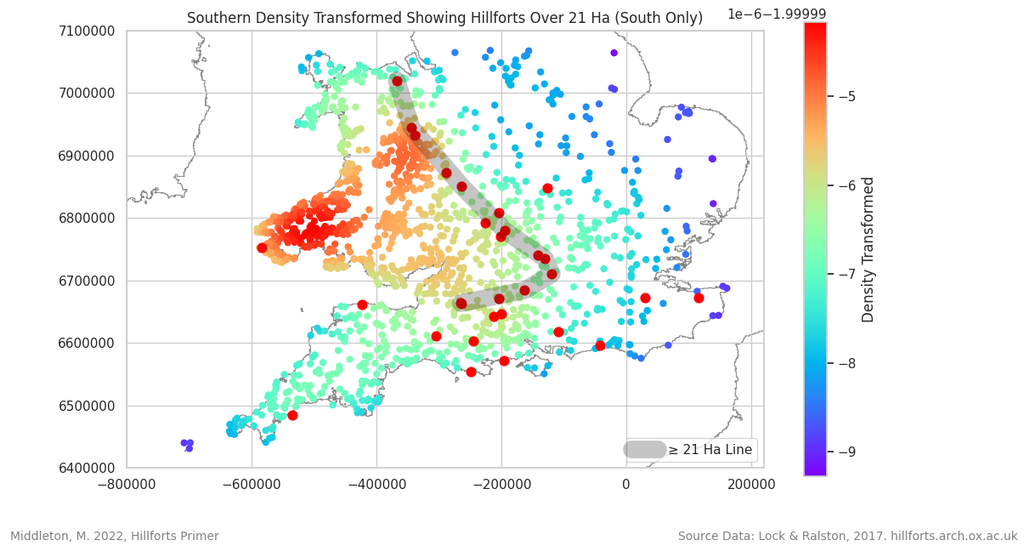

```python
_ , _ = south_density_scatter_lines(cluster_south, enclosing_area_1_21_s, 'Southern Density Transformed Showing Hillforts Over 21 Ha (South Only)', True, False)
```

### Hillforts 21 Ha and over in the South

```python
greater_than_21ha_south = pd.merge(name_and_number, enclosing_area_1_21_s, left_index=True, right_index=True)
twenty_one_ha_and_over_south = greater_than_21ha_south[['Main_Atlas_Number', 'Main_Display_Name', 'Enclosing_Area_1', 'Location_X', 'Location_Y', 'Main_X', 'Main_Y']].copy().sort_values(by='Enclosing_Area_1').style.hide_index()
twenty_one_ha_and_over_south = twenty_one_ha_and_over_south.data
twenty_one_ha_and_over_south
```

|  | Main_Atlas_Number | Main_Display_Name | Enclosing_Area_1 | Location_X | Location_Y | Main_X | Main_Y |
| --- | --- | --- | --- | --- | --- | --- | --- |
| 1127 | 1155 | Penycloddiau, Denbighshire (Pen y Cloddiau) | 21.0 | -367969 | 7019842 | 312888 | 367647 |
| 621 | 643 | Dodman Castle, Cornwall (Dodman Point; The Dod... | 21.0 | -534770 | 6485285 | 200100 | 39850 |
| 731 | 753 | Norbury Camp, Northleach, Gloucestershire | 22.0 | -202278 | 6770873 | 412700 | 215500 |
| 1889 | 1997 | Wooltack Point, Pembrokeshire (Deer Park Fort) | 22.0 | -584307 | 6752378 | 175770 | 209050 |
| 3403 | 3595 | Hod Hill, Dorset | 22.0 | -245476 | 6602754 | 385670 | 110648 |
| 735 | 757 | Salmonsbury Camp, Gloucestershire | 23.0 | -194654 | 6779602 | 417400 | 220900 |
| 357 | 367 | Woodbury, Great Witley, Worcestershire (Woodbu... | 23.0 | -263690 | 6850593 | 374939 | 264523 |
| 136 | 139 | Bozedown Camp, Oxfordshire (Binditch) | 23.5 | -119597 | 6710127 | 464350 | 178250 |
| 3552 | 3749 | Cissbury Ring, West Sussex (Cissbury Camp) | 24.0 | -42657 | 6596650 | 513886 | 108026 |
| 1437 | 1504 | Roulston Scar, North Yorkshire (Sutton Bank; C... | 24.5 | -134884 | 7213231 | 451490 | 481520 |
| 388 | 404 | Ogbury Camp, Wiltshire | 26.0 | -200007 | 6646748 | 414320 | 138294 |
| 443 | 461 | Tedbury Camp, Somerset | 26.0 | -263616 | 6663457 | 374400 | 148800 |
| 373 | 389 | Casterley Camp, Wiltshire (Catterley Banks) | 27.5 | -204306 | 6671153 | 411584 | 153560 |
| 734 | 756 | Willersey Camp, Gloucestershire (Willersey Hil... | 28.0 | -203808 | 6807893 | 411700 | 238300 |
| 410 | 427 | Ebsbury Hill, Wiltshire (Grovely Earthworks) | 28.0 | -212997 | 6642126 | 406160 | 135380 |
| 1234 | 1276 | y Breiddin, Powys (Breddin Hillfort; The Breid... | 28.0 | -338884 | 6931868 | 329570 | 314408 |
| 89 | 91 | Titterstone Clee, Shropshire | 29.6 | -289034 | 6872454 | 359516 | 277973 |
| 3598 | 3795 | Butser Hill, Hampshire | 30.0 | -109375 | 6617356 | 471527 | 120313 |
| 446 | 464 | Wadbury Camp, Somerset (Wadbury Hillfort) | 30.0 | -265052 | 6663609 | 373500 | 148900 |
| 166 | 173 | Abingdon, The Vineyard, Oxfordshire | 33.0 | -142388 | 6740992 | 449950 | 197250 |
| 95 | 97 | Walbury Camp, West Berkshire | 33.0 | -162994 | 6684152 | 437408 | 161800 |
| 3271 | 3459 | Countisbury Castle, Devon (Shoulsbury; Wind Hill) | 35.0 | -423647 | 6662041 | 274024 | 149399 |
| 3625 | 3823 | Homestall Wood, Kent | 35.0 | 115292 | 6672762 | 611760 | 158930 |
| 165 | 172 | Dyke Hills, Oxfordshire (Dike Hills) | 46.0 | -130542 | 6735058 | 457350 | 193650 |
| 738 | 760 | Nottingham Hill Camp, Gloucestershire | 48.6 | -225551 | 6791821 | 398300 | 228400 |
| 3577 | 3774 | Oldbury Camp, Kent | 51.5 | 29679 | 6671658 | 558165 | 156303 |
| 751 | 773 | Borough Hill 1, Northamptonshire (Borough Hill) | 52.0 | -126771 | 6847138 | 458877 | 262696 |
| 194 | 201 | Mull of Galloway, Dumfries & Galloway | 54.0 | -542988 | 7291829 | 214381 | 530735 |
| 70 | 71 | Llanymynech Hill, Powys | 57.0 | -344171 | 6944572 | 326479 | 322138 |
| 3402 | 3594 | Hengistbury Head, Dorset | 80.0 | -195572 | 6571275 | 417263 | 90784 |
| 430 | 448 | Ham Hill, Somerset (Hamdon Hill Camp) | 84.0 | -304545 | 6611780 | 348409 | 116570 |
| 3390 | 3582 | Bindon Hill, Dorset | 114.0 | -248650 | 6554366 | 383568 | 80077 |

```python
download([twenty_one_ha_and_over_south], 'twenty_one_ha_and_over_south')
```

## Hypothosis testing

It is beyond the skills of the author to test the hypothosis of the curved line shown in the image above. This being so, the longer straight section from (1155) Penycloddiau, Denbighshire (Pen y Cloddiau) and (139) Bozedown Camp, Oxfordshire (Binditch) will be tested.

Hypothosis (H1): Hillforts of 21 ha and over are aligned between (1155) Penycloddiau, Denbighshire (Pen y Cloddiau) and (139) Bozedown Camp, Oxfordshire (Binditch).  
Null Hypothosis (H0): Hillforts of 21 ha and over, between (1155) Penycloddiau, Denbighshire (Pen y Cloddiau) and (139) Bozedown Camp, Oxfordshire (Binditch), are not aligned.

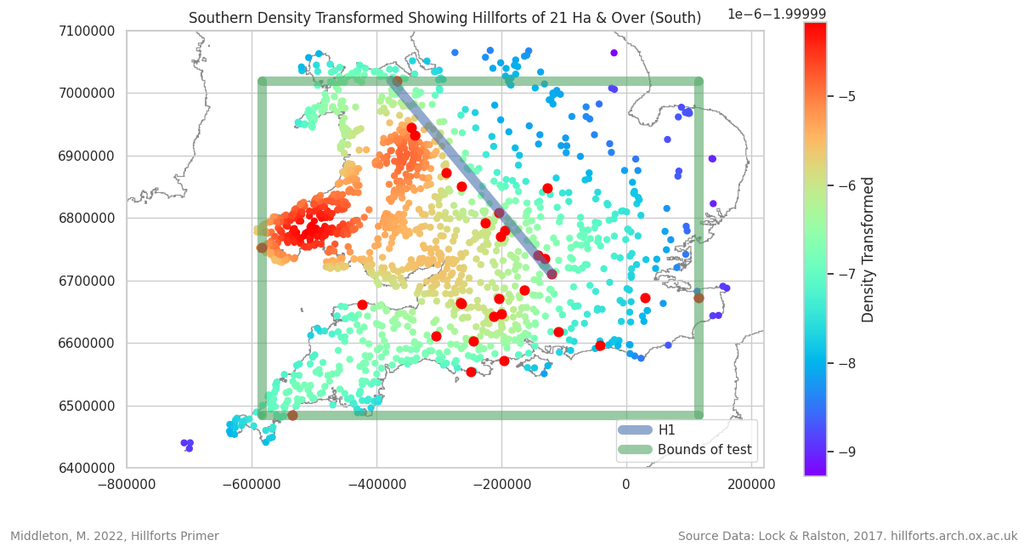

```python
_ , _ = south_density_scatter_lines(cluster_south, enclosing_area_1_21_s, 'Southern Density Transformed Showing Hillforts of 21 Ha & Over (South)', False, False, True, True)
```

The line is 242,511 m (242.5 Km) long.

```python
penycloddiau = (-367969, 7019842)
bozedown = (-119597, 6710127)
dist = math.sqrt( (bozedown[0] - penycloddiau[0])**2 + (bozedown[1] - penycloddiau[1])**2 )
print(f"{round(dist)} units")
```

```
397004 units
```

```python
penycloddiau_m = (312888, 367647)
bozedown_m = (464350, 178250)
dist_m = math.sqrt( (bozedown_m[0] - penycloddiau_m[0])**2 + (bozedown_m[1] - penycloddiau_m[1])**2 )
print(f"{round(dist_m)} m")
```

```
242512 m
```

```python
print(f"Line offset from line {round(dist_m/4.85)} m")
```

```
Line offset from line 50002 m
```

### Random Alignments

To test the hypothesis, 1500 random alignments will be created within the bounds of the forts in the South. The test will measure the perpendicular distance from each hillfort to the line, within a buffer of 50 Km. These distances will be used to calculate the Mean Squared Error (MSE) for all forts falling within the limits of each test alignment. The alignments will all be the same length as the hypothesis line (H1). The perpendicular distance from the line will be classified as the error. The error, for each fort of 21 Ha or above, will be squared and the sum of the squared values, for each line, will be divided by the number of forts that fall within the length of that line. 1500 random alignments will be created but only those with five or more hillforts, within the length of the line will be retained to ensure that the result of the MSE is based on a group of hillforts and not just a couple of individuals. 1500 was chosen to ensure that, at least, 1000 alignments remain after the lines with less than five hillforts have been removed. A single example of a random line is shown below with the perpendicular distances to the line shown.  
The resulting histogram for all 1000+ alignments will be a normal curve with the most common MSE toward the centre and the least toward the edges. For the null hypothesis to be rejected, the test alignment (H1 - the blue line) would be expected to be to the far left of the curve with a probability of less than 5%.  
Shown below are the hillforts perpendicular to the H1 line within an offset distance of 50 km.

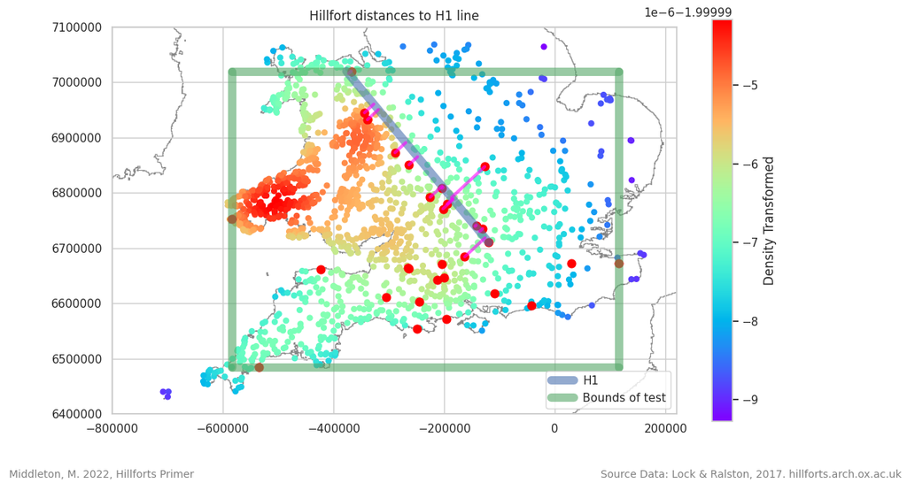

```python
h1_distance_list, _ = south_density_scatter_lines(cluster_south, greater_than_21ha_south, 'Hillfort distances to H1 line', False, False, True, True, True, 0, False, True)
```

The H1 line has 14 hillforts, withing 50 km, along its lenth.

```python
len(h1_distance_list)
```

```
14
```

A random seed is used to ensure that the random numbers created are the same for each run of this document. Below, hillforts perpendicular to the first random alignment are shown.

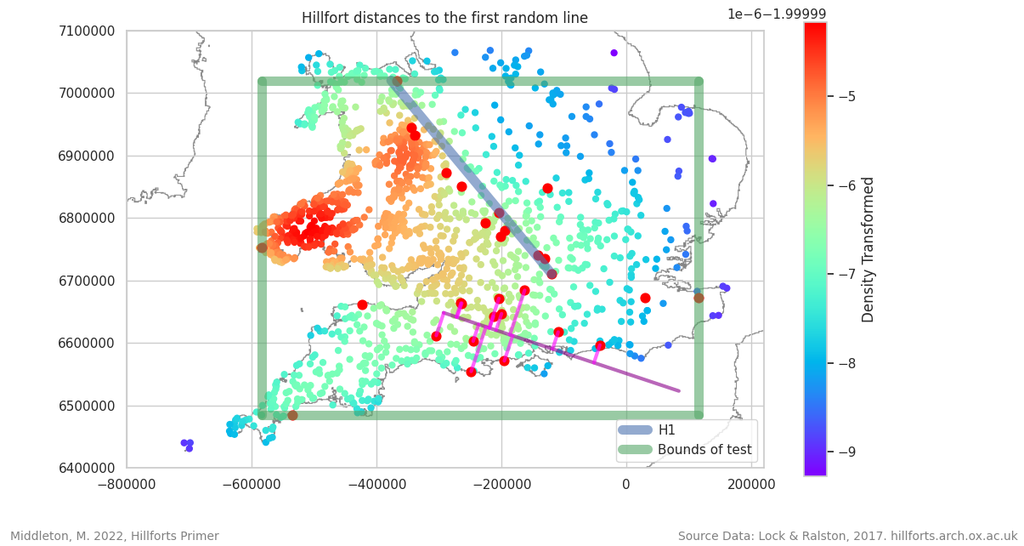

```python
_ , _ = south_density_scatter_lines(cluster_south, enclosing_area_1_21_s, 'Hillfort distances to the first random line', False, False, True, True, True, 1, True)
```

Next, 1500 random alignments area created within the bounds. The distance to hillforts perpendicular to each line are returned for analysis below.

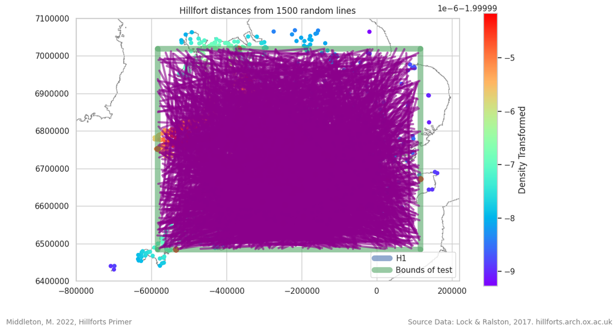

```python
_, distance_lists = south_density_scatter_lines(cluster_south, enclosing_area_1_21_s, 'Hillfort distances from 1500 random lines', False, False, True, True, True, 1500)
```

A list of the number of hillforts in each list is created.

```python
length_list = pd.DataFrame([len(x) for x in distance_lists], columns=["count"])
length_list.head()
```

|  | count |
| --- | --- |
| 0 | 6 |
| 1 | 9 |
| 2 | 15 |
| 3 | 13 |
| 4 | 9 |

```python
length_list.value_counts().sort_index()
```

```
count
0         22
1         62
2         75
3        101
4         91
5        100
6        104
7         85
8         92
9        107
10       116
11       114
12       139
13       132
14        69
15        45
16        28
17        10
18         4
19         4
dtype: int64
```

The filtered list contains 1149 alignments where there are at least 5 or more hillforts perpendicular to the line along the lengh of the line.

```python
filtered_length_list = [x for x in distance_lists if len(x) >= 5]
len(filtered_length_list)
```

```
1149
```

First we get the MSE for the H1 line.

```python
def get_mean_sum_of_squares(lst):
    sum_list = 0
    for i in lst:
        sum_list += i**2
    mse = sum_list/len(lst)
    return mse
```

```python
mse_h1 = int(get_mean_sum_of_squares(h1_distance_list))
mse_h1
```

```
959477730
```

Then we get the MSE for the filterd lines.

```python
mse_list = [int(get_mean_sum_of_squares(x)) for x in filtered_length_list]
mse_df = pd.DataFrame({'mse':mse_list})
mse_df.head()
```

|  | mse |
| --- | --- |
| 0 | 1329023715 |
| 1 | 1832084194 |
| 2 | 3014799598 |
| 3 | 2769225228 |
| 4 | 1299407983 |

### Mean Squared Error (offset)

With these results we can plot a histogram of the MSE data. As anticipated the random alignemnts have produced (more-or-less) a normal curve. The H1 alignement is toward the far left of the curve.

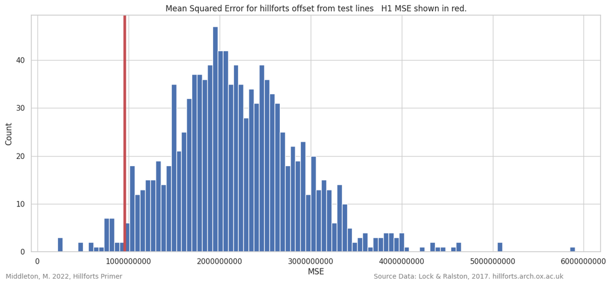

```python
plot_mse_hisogram(mse_list, mse_h1)
```

```python
mse_h1
```

```
959477730
```

A boxplot of the same data shows the interquartile range (IQR) (the blue box) and the first and fourth quarted bounded by the whiskers. The whiskers, on either side of the IQR are located at 2.5% and 97.5%.

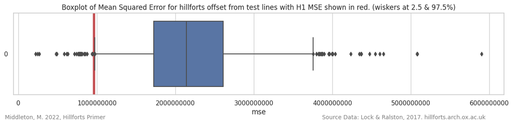

```python
offset_range = plot_data_range_95(mse_list, "mse", "Boxplot of Mean Squared Error for hillforts offset from test lines with H1 MSE shown in red. (wiskers at 2.5 & 97.5%)", "h")
```

```python
print(f"H1 MSE = {round(mse_h1/(offset_range[0]/2.5),2)}%")
```

```
H1 MSE = 2.46%
```

The H1 line (red) has a probabilty of 2.46%, just under 2.5%. Below 2.5% or over 97.5% are routeenly considered the values above and below which the null hypothesis can be rejected.

Hillforts of 21 Ha and over, falling within 50 km of a straight line between (1155) Penycloddiau, Denbighshire (Pen y Cloddiau) and (139) Bozedown Camp, Oxfordshire (Binditch), are aligned.

### Save Figure List

```python
if save_images:
    path = os.path.join(IMAGES_PATH, f"fig_list_{part.lower()}.csv")
    fig_list.to_csv(path, index=False)
```